# Data Collection, Pre-Processing & Visualization using Python

#### Author: Shyam Mohan K. | Email Id: shyam.mk@outlook.com

## Introduction

**The objective of this project is to collect a dataset from one or more open web APIs and use Python to pre-process and analyse the collected data. In this project, we collect, pre-process and analyze the data related to movies. The data is extracted using multiple web-APIs, and pre-processed and analyzed using the python pandas framework.**

```python
# Import the relevant packages required
from IPython.display import display
import csv, json, os, time
import urllib.request
import pandas as pd
import config
```

## [1.] Selection of Relevant Web-APIs

**We have used two web-APIs in this project.**

**(a) TMDb API - https://developers.themoviedb.org/3/getting-started/introduction**

- This is the official API of the The Movie Database (TMDb). For the freely available version, an API key is required, which is provided upon signup and a small amount of rate limiting is enforced. The current limits are 40 requests every 10 seconds and are limited by IP address, not API key. The only format supported by this API is JSON.</b>

**(b) OMDb API - http://www.omdbapi.com/**

- Although unofficial, the OMDb (The Open Movie Database) API is a RESTful web service to obtain movie information from IMDb. An API key is provided after signup, to fetch the movie data and it supports both XML and JSON formats. In our case, we have used the JSON format. For the free version, the rate limit is 1000 requests per day.</b>

```python
# Form the request URLs to fetch the movie data from TMDb
tmdb_latest_movie_url = "https://api.themoviedb.org/3/movie/popular?api_key="+config.tmdb_api_key+"&language=en-US&page="
tmdb_get_imdb_id_url_head = "https://api.themoviedb.org/3/movie/"
tmdb_get_imdb_id_url_tail = "/external_ids?api_key="+config.tmdb_api_key

# Form the request URL to fetch the movie data from OMDb
omdb_get_movie_details_url_head = "http://www.omdbapi.com/?i="
omdb_get_movie_details_url_tail = "&apikey="+config.omdb_api_key
```

**Now that we have chosen the respective web-APIs, we will use them to extract the details of different movies to form our dataset for analysis.**

## [2.] Data Collection using Web-APIs

**First, define a generic function that takes in a URL (API URL request) as an argument, sends the request to the database and retrieves the data. As mentioned earlier, in our project, all the APIs return the data in JSON format. This function returns the JSON object containing the relevant data.**

```python
# Function to fetch the data in a JSON format,using the url passed to it
def getApiURLJsonData(url):
    response = urllib.request.urlopen(url)
    raw_json = response.read().decode('utf-8')
    movie_json = json.loads(raw_json)
    return movie_json
```

**The TMDb API does not return the IMDb ID of the movies, along with the other details. The IMDb ID of the corresponding movie has to be retrieved using a different end-point of the same API. A function is defined below, that returns the IMDb ID of the corresponding movie, by accepting the TMDb ID of the movie as a parameter.**

```python
# Function to retrieve the IMDb ID of a movie
def getIMDbMovieID(tmdb_id):
    tmdb_get_imdb_id_url=tmdb_get_imdb_id_url_head+str(tmdb_id)+tmdb_get_imdb_id_url_tail
    tmdb_external_id_json = getApiURLJsonData(tmdb_get_imdb_id_url)
    imdb_id = tmdb_external_id_json['imdb_id']
    return imdb_id
```

**The below function is to get the ID of the movie in IMDb using the TMDb ID of the movie passed as first parameter, and then use this ID with the OMDb API to retrieve the values for the list of parameters passed as the second argument. It returns a list of values corresponding to the parameters.**

```python
# Function to get all the required details of a movie from IMDb.
def getIMDbMovieDetails(tmdb_id, imdbParamList):
    imdb_details_list = []
    # Retrieve the id of the movie in IMDb
    imdb_id =  getIMDbMovieID(tmdb_id)
    if(imdb_id is None):
        # If no IMDb ID is obtained (or it is of None type), then set 'N/A' as the default value for all the parameters.
        for param in imdbParamList:
            imdb_details_list.append("N/A")
    else:
        # Form the URL, fetch the details of the movie from IMDb and append them to the list.
        omdb_get_movie_details_url = omdb_get_movie_details_url_head+imdb_id+omdb_get_movie_details_url_tail
        imdb_details_json = getApiURLJsonData(omdb_get_movie_details_url)
        if(imdb_details_json['Response']=="True"):
            for param in imdbParamList:
                imdb_details_list.append(imdb_details_json[param])
        else:
            for param in imdbParamList:
                imdb_details_list.append("N/A")

    return imdb_details_list
```

**For every movie, certain details associated with it are fetched from TMDb (using TMDb API) and certain other details from IMDb (using OMDb API). The following function is to fetch the details of a movie from the TMDb and also invoke the other functions to retrieve the corresponding details from IMDb.**

```python
# Function to fetch all the relevant movie details from TMDb API.
def getMovieParamData(movie_data, movieParamList, imdbParamList):
    movieDataList=[]
    for param in movieParamList:
        if(param=='id'):
            # If the parameter is id, then use it to get the IMDb ID and other details from IMDB.
            movieDataList.append(movie_data[param])
            imdb_details_list = getIMDbMovieDetails(movie_data[param], imdbParamList)
            movieDataList[2:1] = imdb_details_list
        else:
            # Append all values to a list
            movieDataList.append(movie_data[param])
    return movieDataList
```

**We have now completed the process of collecting the relevant data from multiple web-APIs (in JSON format). The next step is parsing them and saving them to a file for subsequent analysis.**

### [3.] Data Parsing & Storage in CSV Format

**Define a function to create a CSV file with the required headers. This function takes in a two arguments, the name of the file and the headers to be used in it. Since, we use multiple APIs, the data needs to be combined and placed at a common source, which is the CSV file. Note that we would have two CSV files generated as part of the project, one as the main source of data and the other, is used to get an entry point to the possible future enhancements of this project.**

```python
# Function to create a CSV file with the relevant headers.
def create_file (file_name, headerList):
    # Create (open) the file. The parameter newline = '', in order to prevent blank lines being written.
    with open(file_name, "w", newline='') as write_file:
        f = csv.writer(write_file)
        # Write the headers to the file
        f.writerow(headerList)
    write_file.close()
```

**Create a function to keep appending the final set of movie data identified for our analysis, to the CSV file. The function takes the file name and the list of movie data to be written to the CSV file.**

```python
# Function to append the required movie details to the CSV file.
def writeMovieData(fileName, movieDataList):
    # Open the CSV file. The parameter newline = '', in order to prevent blank lines being written.
    with open(fileName, "a", newline='', encoding='utf-8') as write_file:
        f = csv.writer(write_file)
        # Write the row of movie details identified for analysis
        f.writerow(movieDataList)
    write_file.close()
```

In the below section, we first define the name of the CSV file and invoke the function to create the same. Next, we define two separate lists of parameters to be retrieved through the TMDb and OMDb APIs, respectively. Finally, we define the number of pages to be retrieved from TMDb results (using the URL and TMDb API), iterate through each of them and form the list comprising of all values related to a particular movie. This list is then written as a single row to the CSV file.  
At the moment we are collecting just *40 movie records*. To increase the amount of data retreieved, we may change the *'pageLimit'* parameter accordingly.

```python
# The final CSV file with the combined data from all APIs
fileName="Extracted_Movie_Data.csv"

# Create the CSV file
headerList = ['MovieTitle', 'Id', 'Production', 'Director', 'Runtime', 'Genre', 'Revenue', 'Rated', 'Language', 'ReleaseDate', 'Popularity', 'VoteCount', 'VoteAverage', 'Adult']
create_file(fileName, headerList)

# The list of keys in the resulting JSON file, to be retrieved from the TMDb
movieParamList = ['original_title', 'id', 'release_date', 'popularity', 'vote_count', 'vote_average', 'adult']
# The list of keys in the resulting JSON file, to be retrieved from the IMDb
imdbParamList = ['Production', 'Director', 'Runtime', 'Genre', 'BoxOffice', 'Rated', 'Language']

# Set the no. of result-pages to be retrieved through the TMDb API
pageLimit = 3

for pageNum in range(1, pageLimit):
    # Form the URL string by passing the api_key and the page number
    tmdb_latest_movie_url_new = tmdb_latest_movie_url+str(pageNum)
    # Get the details in JSON format
    movie_json = getApiURLJsonData(tmdb_latest_movie_url_new)
    # Iterate through the JSON object and fetch all the relevant movie details
    for movie_data in movie_json['results']:
        movieDataList=getMovieParamData(movie_data, movieParamList, imdbParamList)
        # Write the final list of values as one row to the CSV file
        writeMovieData(fileName, movieDataList)
        time.sleep(0.300)
```

**Here, we complete the task of parsing the data collected from different APIs and storing them at a single source(a CSV file). We now proceed to loading this data to a dataframe usind pandas and pre-processing them subsequently.**

### [4.] Loading Data to DataFrame & Applying Pre-Processing

### [4.1.] Loading the Data into DataFrame

**Using pandas, the movie data is loaded into a dataframe, directly from the CSV file we generated before. The number of rows and columns in the dataframe, along with a few rows is displayed on the console (using 'shape').**

```python
# Create the dataframe by loading the data from the CSV file, formed earlier.
movieDetailsDataFrame = pd.read_csv(fileName, index_col='Id')

# Get the count of rows & columns in the dataframe, and display them
totalRowCount = movieDetailsDataFrame.shape[0]
totalColCount = movieDetailsDataFrame.shape[1]

# Display the no. of rows and columns in the dataframe
display("Shape of DataFrame:"+str(movieDetailsDataFrame.shape))

# Display first 3 elements of the dataframe to verify the columns and their values
movieDetailsDataFrame.head(5)
```

```
'Shape of DataFrame:(40, 13)'
```

| Id | MovieTitle | Production | Director | Runtime | Genre | Revenue | Rated | Language | ReleaseDate | Popularity | VoteCount | VoteAverage | Adult |
| --- | --- | --- | --- | --- | --- | --- | --- | --- | --- | --- | --- | --- | --- |
| 351286 | Jurassic World: Fallen Kingdom | Universal Pictures | J.A. Bayona | 128 min | Action, Adventure, Sci-Fi | NaN | PG-13 | English, Russian | 2018-06-06 | 299.795 | 1545 | 6.6 | False |
| 260513 | Incredibles 2 | Disney/Pixar | Brad Bird | 118 min | Animation, Action, Adventure | NaN | PG | English | 2018-06-14 | 197.170 | 756 | 7.7 | False |
| 333339 | Ready Player One | Warner Bros. Pictures | Steven Spielberg | 140 min | Action, Adventure, Sci-Fi | NaN | PG-13 | English | 2018-03-28 | 184.301 | 2650 | 7.7 | False |
| 284053 | Thor: Ragnarok | Walt Disney Pictures | Taika Waititi | 130 min | Action, Adventure, Comedy | $314,971,245 | PG-13 | English | 2017-10-25 | 156.228 | 7113 | 7.5 | False |
| 363088 | Ant-Man and the Wasp | Walt Disney Pictures | Peyton Reed | 118 min | Action, Adventure, Sci-Fi | NaN | PG-13 | English | 2018-07-04 | 144.981 | 159 | 7.2 | False |

### [4.2.] Data Pre-Processing

#### [4.2.1.] Drop the Columns that Add No Value

**Now that we have our dataframe, we must pre-process and normalize its contents to extract the best possible insights. In our first step, we take a look at all the columns and figure out which of them would actualy be useful in our analysis.**

**We can see from our dataframe that all the values in the column *'Adult'* are *'False'*. As such, this column is not useful in our analysis. Hence, we can drop it from the dataframe. To confirm this, we first take a count of the no. of rows in the dataframe, where the value in *'Adult'* column is *'False'* and then, compare it with the total rowcount of the dataframe. If both are the same, then we drop the column.**

```python
# Get the count of rows in the dataframe where the value in 'Adult' column is 'False'
adultFalseValRowCount = movieDetailsDataFrame.loc[movieDetailsDataFrame['Adult'] == False]['Adult'].count()
if totalRowCount==adultFalseValRowCount:
    # Drop the 'Adult' column from the dataframe since all the values in the column are the same
    movieDetailsDataFrame = movieDetailsDataFrame.drop(['Adult'], axis=1)

# Display first few elements of the dataframe to verify the columns and their values
movieDetailsDataFrame.head(3)
```

| Id | MovieTitle | Production | Director | Runtime | Genre | Revenue | Rated | Language | ReleaseDate | Popularity | VoteCount | VoteAverage |
| --- | --- | --- | --- | --- | --- | --- | --- | --- | --- | --- | --- | --- |
| 351286 | Jurassic World: Fallen Kingdom | Universal Pictures | J.A. Bayona | 128 min | Action, Adventure, Sci-Fi | NaN | PG-13 | English, Russian | 2018-06-06 | 299.795 | 1545 | 6.6 |
| 260513 | Incredibles 2 | Disney/Pixar | Brad Bird | 118 min | Animation, Action, Adventure | NaN | PG | English | 2018-06-14 | 197.170 | 756 | 7.7 |
| 333339 | Ready Player One | Warner Bros. Pictures | Steven Spielberg | 140 min | Action, Adventure, Sci-Fi | NaN | PG-13 | English | 2018-03-28 | 184.301 | 2650 | 7.7 |

**We can see above that the column *'Adult'*, no longer exists in the dataframe.**

#### [4.2.2.] Handle Missing Values

**In the second step, we figure out all the null or empty values in our dataframe and replace them accordingly.**

```python
# Get the different columns and the no. of missing values in them.
movieDetailsDataFrame.isnull().sum()
```

```
MovieTitle      0
Production      4
Director        1
Runtime         1
Genre           1
Revenue        21
Rated           3
Language        1
ReleaseDate     0
Popularity      0
VoteCount       0
VoteAverage     0
dtype: int64
```

We can observe that, the columns *'Production', 'Director', 'Runtime', 'Genre', 'Revenue', 'Rated' and 'Language'* contain missing values.  
- For the columns, *'Production', 'Director', 'Genre'*, we cannot set any calculated values, as these are all of type 'string'. Hence, we set a default value *'Unknown'* to all the columns.  
- For the column *'Rated'*, we replace the missing values with one of its own values *'NOT RATED'*, whcih matches the situation.  
- For the column *'Language'*, we replace the missing values with the default value *'English'*.  
- For the columns *'Runtime' and 'Revenue'*, we set the values *'0 min' and '$0'*, respectively. *But these two values are temporary and would be replaced in further steps.*  
In the below section we fix them as mentioned.

```python
# Replace all missing values in the columns 'Production', 'Director', 'Genre' & 'Rated'
movieDetailsDataFrame["Production"] = movieDetailsDataFrame["Production"].fillna("Unknown")
movieDetailsDataFrame["Director"] = movieDetailsDataFrame["Director"].fillna("Unknown")
movieDetailsDataFrame["Genre"] = movieDetailsDataFrame["Genre"].fillna("Unknown")
movieDetailsDataFrame["Rated"] = movieDetailsDataFrame["Rated"].fillna("NOT RATED")

# Replace all missing values in the column 'Language'
movieDetailsDataFrame["Language"] = movieDetailsDataFrame["Language"].fillna("English")

# Replace all missing values in the column 'Runtime' (temporary replacement)
movieDetailsDataFrame["Runtime"] = movieDetailsDataFrame["Runtime"].fillna("0 min")

# Replace all missing values in the column 'Revenue' (temporary replacement)
movieDetailsDataFrame["Revenue"] = movieDetailsDataFrame["Revenue"].fillna("$0")
```

#### [4.2.3.] Convert Column Types

Now let us convert the types of certain columns that are currently of type 'string'.  
- The column *'ReleaseDate'*, needs to be converted from string to datetime, as it contains date values.  
- Similarly, the columns *'Runtime' and 'Revenue'* need to be converted from string to int and float, respectively.  
We will also rename the columns *'Runtime' & 'Revenue'* accordingly, so that it is easily readable and understandable.

```python
# Convert the type of the column 'ReleaseDate' from string to datetime
movieDetailsDataFrame['ReleaseDate'] = pd.to_datetime(movieDetailsDataFrame['ReleaseDate'])

# Convert the type of the columns 'Runtime' & 'Revenue' from string to numeric
movieDetailsDataFrame['Runtime'] = movieDetailsDataFrame['Runtime'].replace('[ min]', '', regex=True)
movieDetailsDataFrame['Runtime'] = pd.to_numeric(movieDetailsDataFrame['Runtime'])
movieDetailsDataFrame['Revenue'] = movieDetailsDataFrame['Revenue'].replace('[\$,]', '', regex=True)
movieDetailsDataFrame['Revenue'] = pd.to_numeric(movieDetailsDataFrame['Revenue'])

# Rename the columns 'Runtime' & 'Revenue', for easy readability
movieDetailsDataFrame = movieDetailsDataFrame.rename(columns={'Revenue': 'Revenue($)', 'Runtime': 'Runtime(mins)'})
```

Now that we have converted the types of the columns *'Runtime' and 'Revenue'* and also renamed them, let us complete the pending task of replacing the missing values in these columns. Recall that earlier, we had set temporary values in these columns.  
Since, these are numeric fields, let us calculate the mean of these two columns and then set the same as the default value for both these columns.

```python
# Calculate the mean of columns 'Runtime' & 'Revenue' and round them off accordingly.
mean_runtime = round(movieDetailsDataFrame['Runtime(mins)'].mean(), 2)
mean_revenue = round(movieDetailsDataFrame['Revenue($)'].mean(), 3)

# Now replace the temporary values set earlier, in these columns
movieDetailsDataFrame["Runtime(mins)"] = movieDetailsDataFrame["Runtime(mins)"].replace(0, mean_runtime)
movieDetailsDataFrame["Revenue($)"] = movieDetailsDataFrame["Revenue($)"].replace(0, mean_revenue)
```

#### [4.2.4.] Normalize/Scale the Numeric Values

**All the numeric values in the dataframe must be normalized or brought to the same range, for effective results to be obtained as a result of the analysis.**

We can see that, all the values in the columns *'Runtime(mins)', 'Revenue($)', 'Popularity', 'VoteCount' and 'VoteAverage'* are not in the same range. Hence, we apply *min-max normalization* on the values in all these columns, except *'VoteAverage'*. To do this, we take the minimum and maximum values in each of these columns and, then apply the formula *(val-min)/(max-min)* to normalize the values.  
In case of the column *'VoteAverage'*, we just divide each of its values by 10, since it is already in the range of 0-10.

```python
# Normalize the values of the columns 'Runtime(mins)', 'Revenue($), 'Popularity' & 'VoteCount' using min-max normalization
movieDetailsDataFrame['Runtime(mins)'] = (movieDetailsDataFrame['Runtime(mins)'] - movieDetailsDataFrame['Runtime(mins)'].min())/(movieDetailsDataFrame['Runtime(mins)'].max() - movieDetailsDataFrame['Runtime(mins)'].min())
movieDetailsDataFrame['Revenue($)'] = (movieDetailsDataFrame['Revenue($)'] - movieDetailsDataFrame['Revenue($)'].min())/(movieDetailsDataFrame['Revenue($)'].max() - movieDetailsDataFrame['Revenue($)'].min())
movieDetailsDataFrame['Popularity'] = (movieDetailsDataFrame['Popularity'] - movieDetailsDataFrame['Popularity'].min())/(movieDetailsDataFrame['Popularity'].max() - movieDetailsDataFrame['Popularity'].min())
movieDetailsDataFrame['VoteCount'] = (movieDetailsDataFrame['VoteCount'] - movieDetailsDataFrame['VoteCount'].min())/(movieDetailsDataFrame['VoteCount'].max() - movieDetailsDataFrame['VoteCount'].min())

# Scale the values of the column 'VoteAverage' to bring it to the range(0,1)
movieDetailsDataFrame['VoteAverage'] = movieDetailsDataFrame['VoteAverage']/10
```

#### [4.2.5.] Create Any New Columns Required

**Once pre-processing is done, we will create two new columns *'ReleaseMonth'* and *'ReleaseYear'* from the existing *'ReleaseDate'* column, which will further help our analysis using plots.**

```python
# Import the datetime package
from datetime import datetime as dt

# Create two new columns in the dataframe to represent the Month & Year of Release, respectively.
movieDetailsDataFrame['ReleaseMonth'] = movieDetailsDataFrame['ReleaseDate'].dt.strftime('%b')
movieDetailsDataFrame['ReleaseYear'] = movieDetailsDataFrame['ReleaseDate'].dt.strftime('%Y')

# Display first 3 elements of the dataframe to verify the columns and their values
movieDetailsDataFrame[0:3]
```

| Id | MovieTitle | Production | Director | Runtime(mins) | Genre | Revenue($) | Rated | Language | ReleaseDate | Popularity | VoteCount | VoteAverage | ReleaseMonth | ReleaseYear |
| --- | --- | --- | --- | --- | --- | --- | --- | --- | --- | --- | --- | --- | --- | --- |
| 351286 | Jurassic World: Fallen Kingdom | Universal Pictures | J.A. Bayona | 0.605634 | Action, Adventure, Sci-Fi | 0.148388 | PG-13 | English, Russian | 2018-06-06 | 1.000000 | 0.100862 | 0.66 | Jun | 2018 |
| 260513 | Incredibles 2 | Disney/Pixar | Brad Bird | 0.464789 | Animation, Action, Adventure | 0.148388 | PG | English | 2018-06-14 | 0.603099 | 0.049321 | 0.77 | Jun | 2018 |
| 333339 | Ready Player One | Warner Bros. Pictures | Steven Spielberg | 0.774648 | Action, Adventure, Sci-Fi | 0.148388 | PG-13 | English | 2018-03-28 | 0.553329 | 0.173047 | 0.77 | Mar | 2018 |

**With this, we completed loading the data from CSV into dataframe and data pre-processing. We dropped the columns that do not add any value to the analysis, handled/replaced missing values, converted column types and normalized/scaled the numeric values.**

### [5.] Summarizing the Analysis

**We now summarize our analysis using different plots and graphical representations. All the interpretations, insights and conclusions drawn from this dataset would be brought to the table, in this section.**

#### [5.1.] No. of Movies Released Per Month

**Our objective here, is to plot a bar graph that displays the number of movies released per month, irrespective of the year.**

```python
# Define a list containing the names/abbreviations of months in a year
uniqueMonthList = ['Jan', 'Feb', 'Mar', 'Apr','May','Jun', 'Jul', 'Aug','Sep', 'Oct', 'Nov', 'Dec']

# Create a new smaller dataframe with the 'ReleaseMonth' and the no. of movies released per month
movieReleaseMonthDataFrame = pd.DataFrame(movieDetailsDataFrame['ReleaseMonth'].value_counts())
movieReleaseMonthDataFrame.index = pd.CategoricalIndex(movieReleaseMonthDataFrame.index, categories=uniqueMonthList, sorted=True)
movieReleaseMonthDataFrame = movieReleaseMonthDataFrame.sort_index()
```

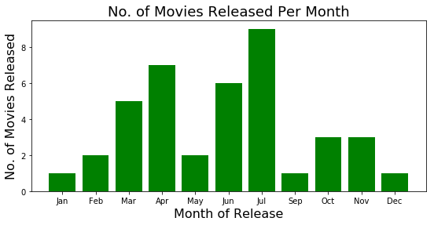

```python
# Import the required libraries to plot the graphs
import matplotlib, pylab
import matplotlib.pyplot as plt
%matplotlib inline

# Set the corresponding positions on the y-axis
y_pos = range(len(movieReleaseMonthDataFrame.index.values))

# Create a new figure & set the canvas size
plt.figure(figsize=(9,4))

# Plot the bar chart
bars = plt.bar(y_pos, movieReleaseMonthDataFrame['ReleaseMonth'], align='center', color='green')
plt.xticks(y_pos, movieReleaseMonthDataFrame.index.values)
plt.xlabel("Month of Release", fontsize=16)
plt.ylabel("No. of Movies Released", fontsize=16)
plt.title("No. of Movies Released Per Month", fontsize=18)
plt.show()
```

**We can see that most number of movies are released in *_July_*. Similarly, we can also create graphs for determining the year, day of month or day of week, when maximum number of movies were released.**

#### [5.2.] Distribution of 'Runtime' Feature across the Dataset

**This histogram plotted below, portrays the distribution of the attribute *'Runtime(mins)'* using its frequencies across our dataset.**

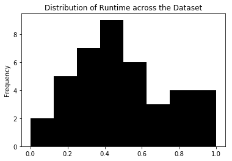

```python
obj = movieDetailsDataFrame["Runtime(mins)"].plot(kind="hist", title="Distribution of Runtime across the Dataset", bins=8, color='black')
```

#### [5.3.] Relationship between Popularity & Revenue

**Here, we try to understand if there is a *directly proportional* relationship between the popularity of a movie among the audience and its box-office collection.**

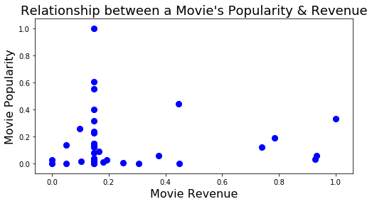

```python
# Create a new smaller dataframe containing the 'ReleaseDate', 'ReleaseMonth', 'ReleaseYear', 'Popularity' & 'Revenue($)'
moviePopularityRevenueDf = movieDetailsDataFrame[['Popularity', 'Revenue($)']]

# Sort the dataframe based on the column 'Popularity'
moviePopularityRevenueDf = moviePopularityRevenueDf.sort_values(by='Popularity', ascending=False)[0:50]

# Plot a line graph with the values
plt.figure(figsize=(8,4))
p = plt.scatter(moviePopularityRevenueDf['Revenue($)'], moviePopularityRevenueDf['Popularity'], color="blue", s=65)

# Set the labels for both the axes and also set the title of the graph
plt.xlabel('Movie Revenue', fontsize=16)
plt.ylabel('Movie Popularity', fontsize=16)
plt.title("Relationship between a Movie's Popularity & Revenue", fontsize=18)
```

**We can infer from the plotted graph that the movies with huge popularity may not necessarily be the ones with the most revenue at the box-office. Hence, we can conclude that there is no *directly proportional* relationship between the poularity and revenue of movies.**

#### [5.4.] Variations in Revenue and Vote Average across Months

**We try to figure out how the box office collections and the average of audience votes for a movie, vary across the different months of a year.**

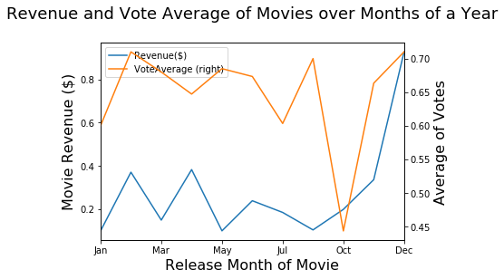

```python
# Create a smaller dataframe containing the mean revenue and vote average, grouped by the month of release
yearly_Group = movieDetailsDataFrame[['ReleaseMonth', 'Revenue($)', 'VoteAverage']].groupby('ReleaseMonth').agg('mean')
yearly_Group.index = pd.CategoricalIndex(yearly_Group.index, categories=uniqueMonthList, sorted=True)
yearly_Group = yearly_Group.sort_index()

# Plot a dual-axis graph representing how the mean revenue and vote average change with months
revVotePlt = yearly_Group.plot(secondary_y=['VoteAverage'])
revVotePlt.set_ylabel("Movie Revenue ($)", fontsize=16)
revVotePlt.set_xlabel("Release Month of Movie", fontsize=16)
revVotePlt.right_ax.set_ylabel("Average of Votes", fontsize=16)

plt.title("Revenue and Vote Average of Movies over Months of a Year\n", fontsize=18)
plt.show()
```

**The above graph can be split into sub-plots as shown below.**

```
array([<matplotlib.axes._subplots.AxesSubplot object at 0x0000016ACDFEBCF8>,
       <matplotlib.axes._subplots.AxesSubplot object at 0x0000016ACE1D1198>], dtype=object)
```

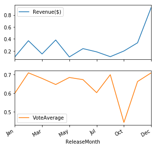

```python
yearly_Group.plot(subplots=True, figsize=(5, 5))
```

#### [5.5.] Revenue Distribution across Months, for every Year of Release

**We try to figure out the box office collections of each month in each year of release, for all the movies. This is represented using a heatmap, as shown below.**

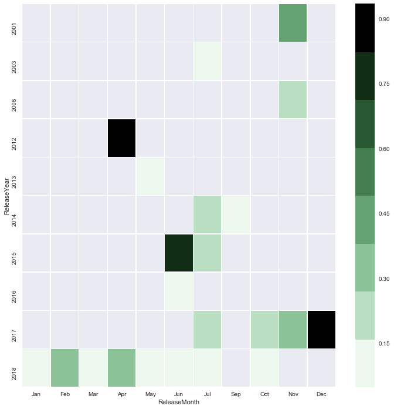

```python
import seaborn as sns
from matplotlib.colors import ListedColormap

# Create a copy of the main dataframe that contains only the columns 'ReleaseMonth', 'ReleaseYear','Revenue($)'
monthYearGroupDf = movieDetailsDataFrame[['ReleaseMonth', 'ReleaseYear','Revenue($)']].copy()
# Convert the columns 'ReleaseMonth' & 'ReleaseYear' to categorical variables
monthYearGroupDf['ReleaseMonth'] = pd.CategoricalIndex(monthYearGroupDf['ReleaseMonth'], categories=uniqueMonthList, sorted=True)
monthYearGroupDf['ReleaseYear'] = monthYearGroupDf['ReleaseYear'].astype('category')

# Plot a heatmap using seaborn
fig,ax = plt.subplots(figsize=(12,12))
my_cmap = ListedColormap(sns.cubehelix_palette(8, start=2, rot=0, dark=0, light=.95))
sns.heatmap(monthYearGroupDf.pivot_table(index='ReleaseYear', columns='ReleaseMonth', values='Revenue($)'),
            cmap=my_cmap, ax=ax, linewidth=0.5)
```

**It can be inferred that the highest revenue was obtained for the movies released in *April, 2012 and December, 2017*.**

#### [5.6.] Popular Movies & their Directors, with Certification

**Similar to the above plot, the below heatmap represents the popularity of movies directed by a director along with its certification.**

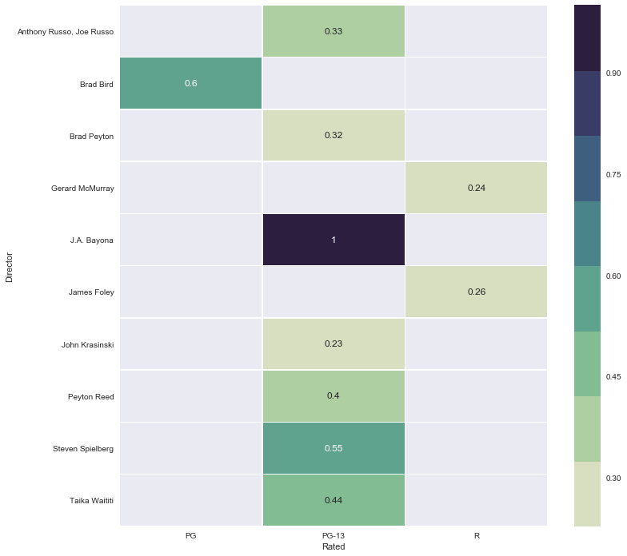

```python
# Create a copy of the main dataframe that contains only the columns 'ReleaseMonth', 'ReleaseYear','Revenue($)'
directorGroupDf = movieDetailsDataFrame[['Rated', 'Director', 'Popularity']].copy()
directorGroupDf = directorGroupDf.sort_values(by='Popularity', ascending=False)[0:10]

# Convert the columns 'ReleaseMonth' & 'ReleaseYear' to categorical variables
for ctg in ['Rated', 'Director']:
    directorGroupDf[ctg] = directorGroupDf[ctg].astype('category')

my_cmap = ListedColormap(sns.cubehelix_palette(8, start=.5, rot=-.75))
fig,ax = plt.subplots(figsize=(12,12))
sns.heatmap(directorGroupDf.pivot_table(index='Director', columns='Rated', values='Popularity'),
            cmap=my_cmap, ax=ax, linewidth=0.5, annot=True)
```

**From the top 10 popular movies we selected from the dataframe, we see that the highest popularity was obtained for the movie directed by *_J.A.Bayona_* which was certified/rated as *PG-13***.

#### [5.7.] Connecting the Different Features in the Dataset

**The below representation involves plotting our attributes *'Popularity', 'VoteAverage', 'Revenue($)' and 'Runtime(mins)'* on a different column and then connecting them using lines for each row (data point) in the dataframe. This is done to understand the relationship between these attributes and a movie's rating/certification.**

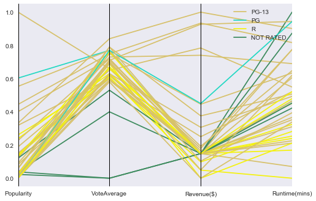

```python
# Copy the columns 'Popularity', 'VoteAverage', 'Revenue($)', 'Runtime(mins)' & 'Rated', to a new dataframe
tempDataFrame = movieDetailsDataFrame[['Popularity', 'VoteAverage', 'Revenue($)', 'Runtime(mins)', 'Rated']].copy()

# Plot the values using parallel co-ordinates
from pandas.plotting import parallel_coordinates
parCord = parallel_coordinates(tempDataFrame, "Rated")
```

**The lines in the below figure are coloured based on the values in the *'Rated'* column. We understand that there is a high convariance between these features.**

#### [5.8.] No. of Movies Per Rating (Certification)

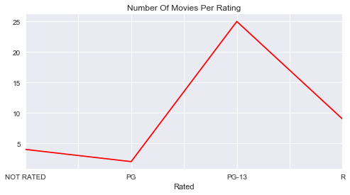

```python
ratedDataFrame = movieDetailsDataFrame[['MovieTitle', 'Rated']].copy()
ratedDataFrame = ratedDataFrame.groupby('Rated').count()

p = ratedDataFrame["MovieTitle"].plot(title="Number Of Movies Per Rating", figsize=(8,4), color='red')
```

## [6.] Conclusion

**In the above steps, we used multiple web-APIs to retrieve the data related to movies, parsed and combined them to a single CSV file, pre-processed the data and finally, created some visualizations based on our analysis.**

**Through a series of steps, we were able to analyze and understand the following:**

- *In which month of a year, the most number of movies are released.*
- *Identify the pattern of distribution of the runtime of a movie across our dataset.*
- *Nature of relationship between the Popularity and Revenue of a movie.*
- *How the Revenue and Average of Votes, vary across different months in a year.*
- *Identify the pattern of Revenue Distribution across different months, for every Year of Release.*
- *The top-10 Directors and Ratings for their movies, based on the Popularity of the movies.*
- *How the different attributes of our dataset are connected to each other, based on the Ratings(certifications) of the movies.*
- *The number of movies per Rating/Certification.*</b>

**The point to note here is that, these conclusions are tentative and may be vary (or) remain same/smiliar when analyzed on huge datasets. At the moment, these results are based on 40 popular movies collected using multiple APIs.**

## [7.] References

1. https://developers.themoviedb.org/3
2. http://www.omdbapi.com/
3. https://pandas.pydata.org/pandas-docs/stable/
4. https://matplotlib.org/faq/usage_faq.html
5. https://seaborn.pydata.org/tutorial/color_palettes.html
6. https://seaborn.pydata.org/generated/seaborn.heatmap.html
7. COMP41680 - Lecture Slides, by Prof. Derek Greene
8. COMP41680 - Lab Tutorial Notebooks, by Prof. Derek Greene </b>